# Covid 19 Pandemic in Brazil

Prabhath Tharinda

9/25/2021

## **1 Background**

[figure not shown]

### **1.1 Introduction**

Brazil is the largest country in South America and the fifth largest nation in the world. It forms an enormous triangle on the eastern side of the continent with a 4,500-mile (7,400-kilometer) coastline along the Atlantic Ocean. It has borders with every South American country except Chile and Ecuador. The Brazilian landscape is very varied. It is most well known for its dense forests, including the Amazon, the world’s largest jungle, in the north. But there are also dry grasslands (called pampas), rugged hills, pine forests, sprawling wetlands, immense plateaus, and a long coastal plain. Northern Brazil is dominated by the Amazon River and the jungles that surround it. The Amazon is not one river but a network of many hundreds of waterways. Its total length stretches 4,250 miles (6,840 kilometers). Thousands of species live in the river, including the infamous piranha and the boto, or pink river dolphin.

### **1.2 Location of Brazil**

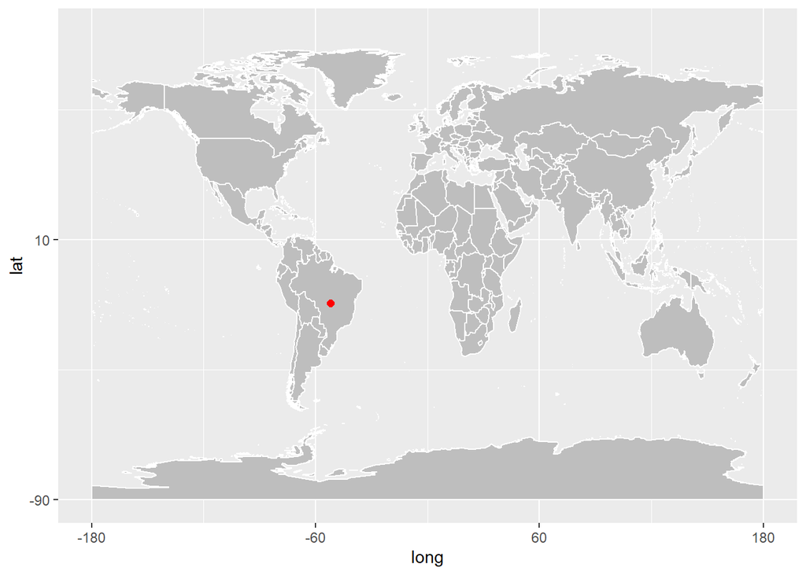

Geographical location of Brazil

### **1.3 Climate condition**

Brazil has a humid tropical and subtropical climate except for a drier area in the Northeast, sometimes called the drought quadrilateral or drought polygon, that extends from northern Bahia to the coast between Natal and São Luís; that zone receives about 15–30 inches (375–750 mm) of precipitation a year. Much of Brazil receives 40–70 inches (1,000–1,800 mm) annually, but precipitation often is much heavier in parts of the Amazon basin and the sea-facing rim of the Serra do Mar. The central parts of the Brazilian Highlands receive most of their precipitation during the summer months (November to April), often in the form of torrential downpours. Storms and floods may strike the Northeast at that time, depending on weather patterns, but the region may also experience prolonged drought. These shifting conditions make life difficult in the sertão, the backlands of the Northeast, and are a major cause for migration out of the region. Summer temperatures are largely uniform. In January most of the lowlands average roughly 79 °F (26 °C), and the highlands are a few degrees cooler, depending on elevation. The coast of Rio Grande do Sul is also somewhat cooler, averaging around 73 °F (23 °C), whereas the Northeast backland’s drought quadrilateral, the hottest region of the country, averages some 84 °F (29 °C), with daytime temperatures exceeding 100 °F (38 °C). However, the Northeast’s low humidity makes the heat less oppressive than in Rio de Janeiro. In the winter (May to October) the Brazilian Highlands are generally dry, and snow falls in only a few of the southernmost states. Regular frosts accompany winter air patterns from the south, and near-freezing temperatures can reach as far north as São Paulo. Cool, rainy weather may extend along the coast as far north as Recife and, in the west, to the Pantanal. Cool air occasionally spills over from the Paraguay lowlands into the western Amazon basin and may travel as far north as the Guyana border. Winter temperatures in the Amazon lowlands remain virtually unchanged from those of the summer months, but temperatures in the drought quadrilateral drop to about 79 °F (26 °C). Temperatures in the Brazilian Highlands average about 68 °F (20 °C) in the central and northern regions and are cooler toward the south: Curitiba, at an elevation of some 3,000 feet (900 metres), averages 57 °F (14 °C) in June and July. During those months the mean temperature at Porto Alegre is the same, but Rio de Janeiro is much hotter, averaging 73 °F (23 °C), partly because of the warm currents that bathe the entire Brazilian coast.

### **1.4 Lock-down status of Brazil**

In these days(26 September 2021) Brazil is not lock down.Because President and the Government has pursued a herd immunity strategy.

### **1.5 Actions taken by the government**

Under the leadership of president Jair Bolsonaro, the federal government in Brazil has failed to implement a systematic plan to prevent the spread covid-19. Instead, under the pretext of shortening the public health crisis and protecting the economy, the Brazilian government has pursued a herd immunity strategy. That is one of the resons of increasing covid active cases and deaths. Thousands of people infacted and die in day by day.

## **2 Exploratory Data Analysis**

### **2.1 Visualization of death, confirmed, recovered, active cases**

### Qualitative data

date - The date of the summary,

province - The province or state, when applicable,

country - The country or region name,

type - the type of case (i.e., confirmed, death),

### Quantitative data

lat - Latitude point,

long - Longitude point,

cases - the number of daily cases (corresponding to the case type),

### **Summary of Brazil data set**

```
##       date              province           country               lat
##  Min.   :2020-01-22   Length:1773        Length:1773        Min.   :-14.23
##  1st Qu.:2020-06-17   Class :character   Class :character   1st Qu.:-14.23
##  Median :2020-11-12   Mode  :character   Mode  :character   Median :-14.23
##  Mean   :2020-11-12                                         Mean   :-14.23
##  3rd Qu.:2021-04-09                                         3rd Qu.:-14.23
##  Max.   :2021-09-18                                         Max.   :-14.23
##       long            type               cases
##  Min.   :-51.93   Length:1773        Min.   :     0
##  1st Qu.:-51.93   Class :character   1st Qu.:   684
##  Median :-51.93   Mode  :character   Median :  6895
##  Mean   :-51.93                      Mean   : 22331
##  3rd Qu.:-51.93                      3rd Qu.: 37884
##  Max.   :-51.93                      Max.   :388340
```

### **Total number of confirmed cases reported from Brazil**

```
## [1] 21230325
```

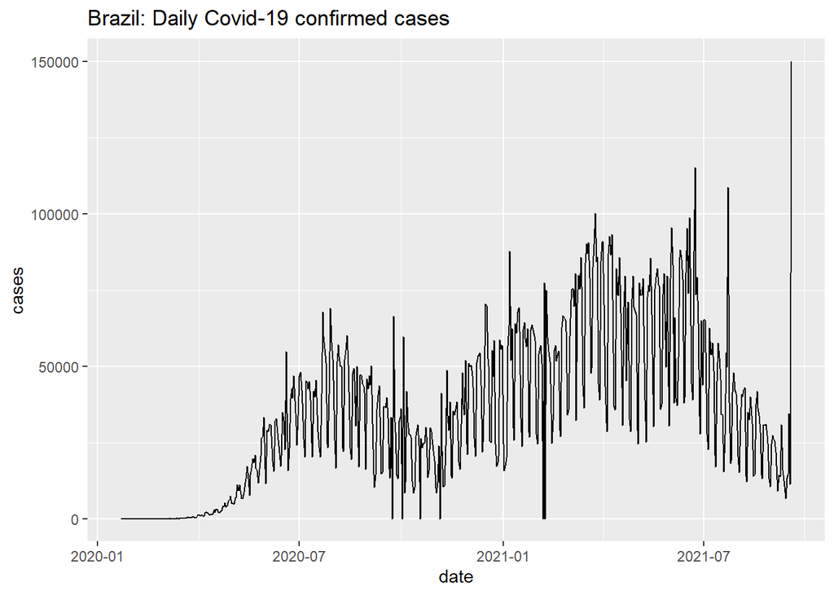

This is the graphical interpret daily confirmed cases have been changed over the time.There is a random increasing and decreasing pattern in data.

### **Total number of death cases reported from Brazil**

```
## [1] 590508
```

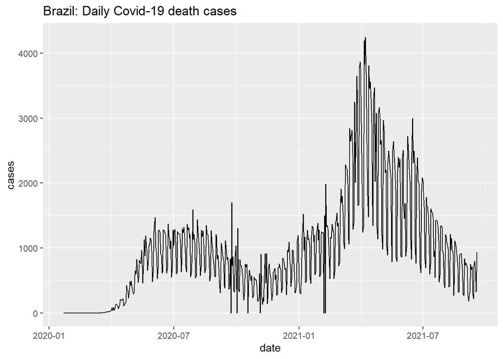

### **Total number of recovered cases reported from Brazil**

```
## [1] 17771228
```

This is the graphical interpret daily recovered cases have been changed over the time.

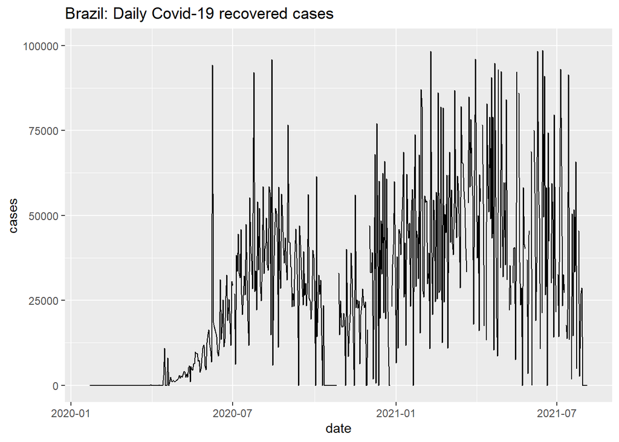

This is the graphical interpret daily recovered cases have been changed over the time. According to the data recovering rate is law precentage than confirmed cases.

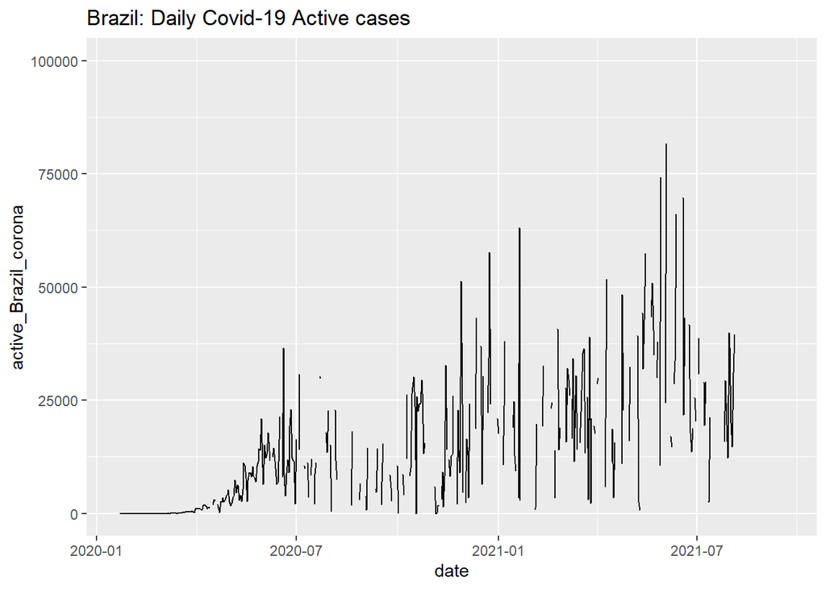

### **Graphically represent all three confirmed,recovered & death cases**

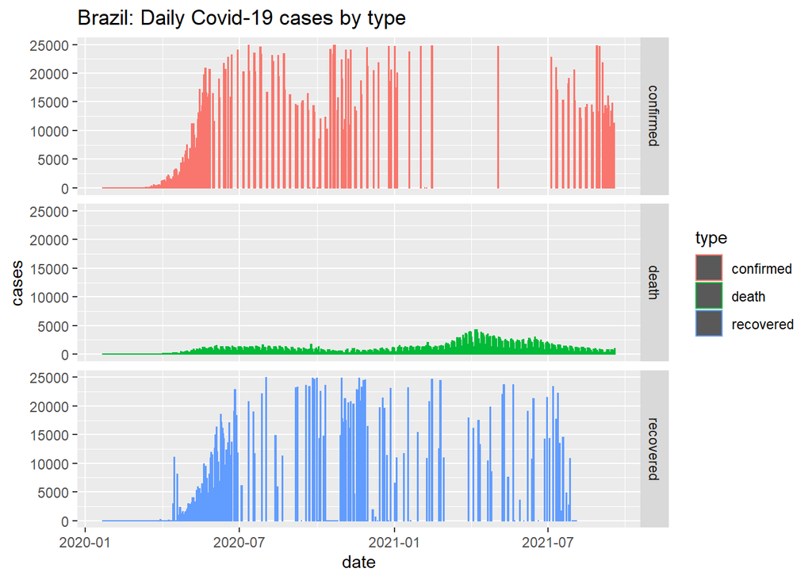

### **Percentage of deaths due to covid 19 in Brazil**

```
## [1] 2.781436
```

### **2.2 Comparison with other countries**

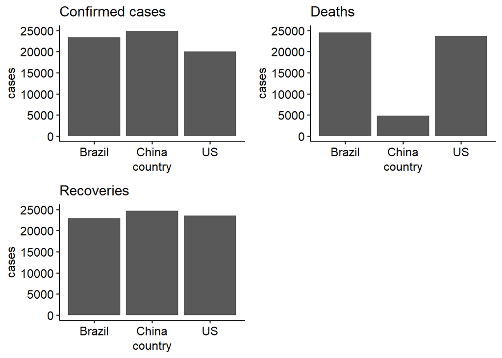

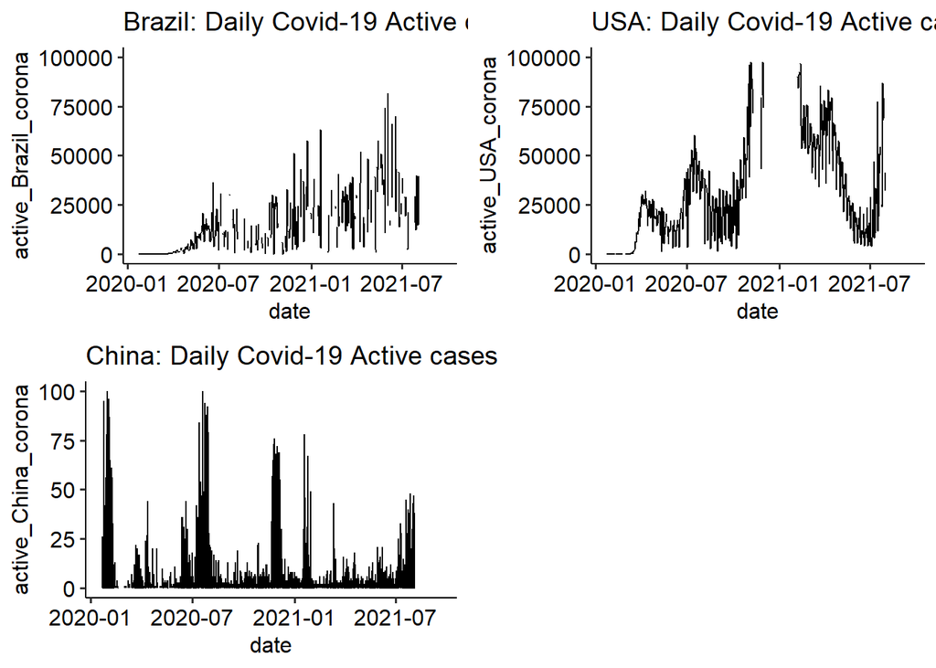

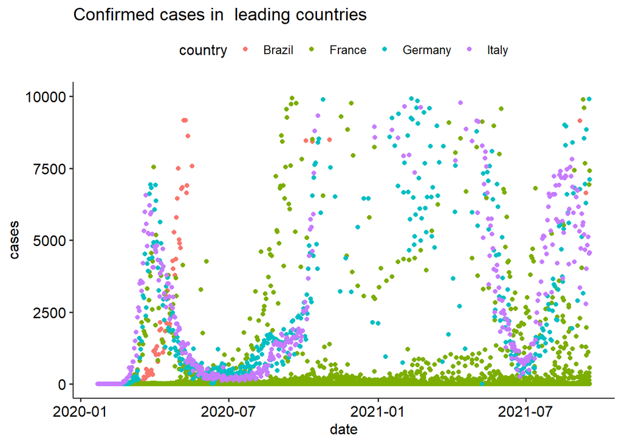

## **5 References**

https://www.aljazeera.com

https://graphics.reuters.com/world-coronavirus-tracker-and-maps/countries-and-territories/brazil/

https://www.bbc.com/news/world-latin-america-18909529 https://www.bbc.com/news/world-latin-america-18909529